# NEURALNET PRESENTATION

Marc XU

– mars 2019

# Neuron Network

# Données PLACENTA

## Les données PLACENTA

```
[1]  90 208
```

| CI | ast_fraglike | ast_fraglike_ext | ast_violation | a_don |
| --- | --- | --- | --- | --- |
| 0.47 | 0 | 0 | 1 | 3 |
| 0.25 | 1 | 1 | 0 | 0 |
| 0.17 | 0 | 0 | 1 | 3 |
| 0.30 | 1 | 1 | 0 | 0 |
| 0.75 | 0 | 0 | 2 | 0 |
| 0.47 | 1 | 0 | 0 | 2 |

## Résumés des données

```
       CI          ast_fraglike ast_fraglike_ext ast_violation
 Min.   :0.0200   Min.   :0.0   Min.   :0.0000   Min.   :0.000
 1st Qu.:0.2325   1st Qu.:0.0   1st Qu.:0.0000   1st Qu.:0.000
 Median :0.3850   Median :0.0   Median :0.0000   Median :1.000
 Mean   :0.4561   Mean   :0.3   Mean   :0.1667   Mean   :1.233
 3rd Qu.:0.7275   3rd Qu.:1.0   3rd Qu.:0.0000   3rd Qu.:2.000
 Max.   :1.0700   Max.   :1.0   Max.   :1.0000   Max.   :4.000
     a_don
 Min.   :0.000
 1st Qu.:0.000
 Median :2.000
 Mean   :1.844
 3rd Qu.:3.000
 Max.   :8.000
```

## ACP (sans normalisé)

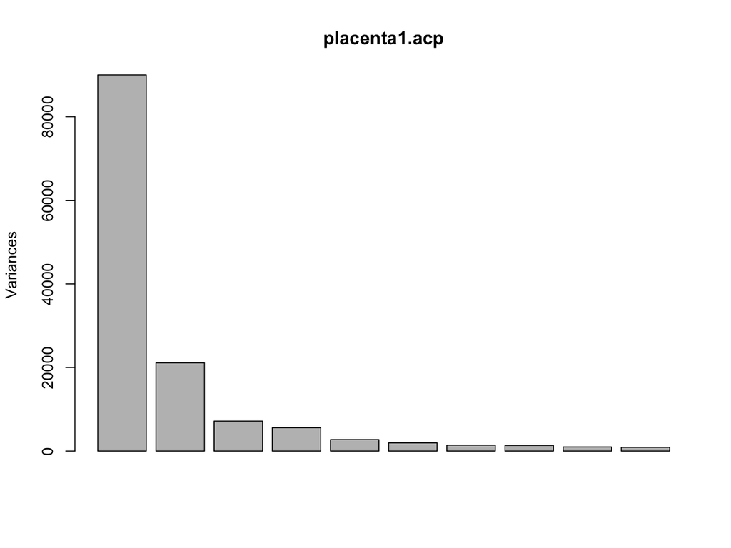

## ACP (sans normalisé)

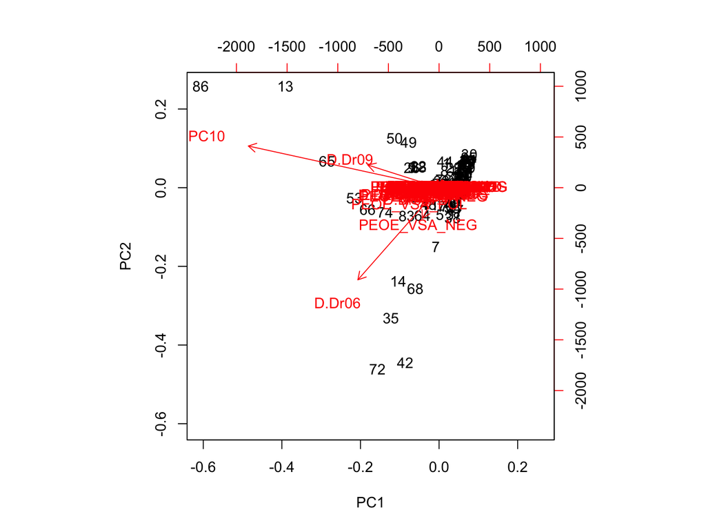

## ACP (normalisé)

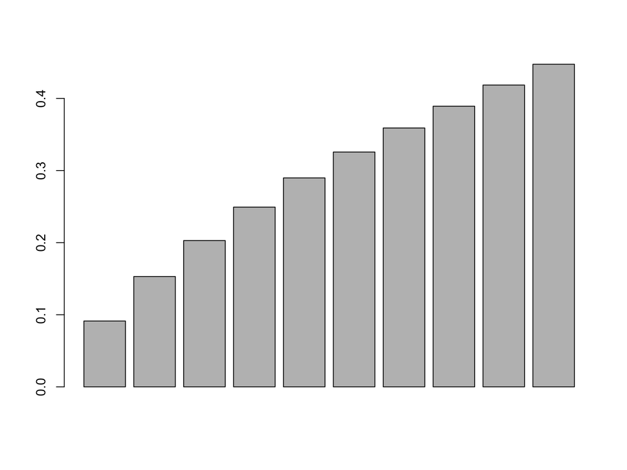

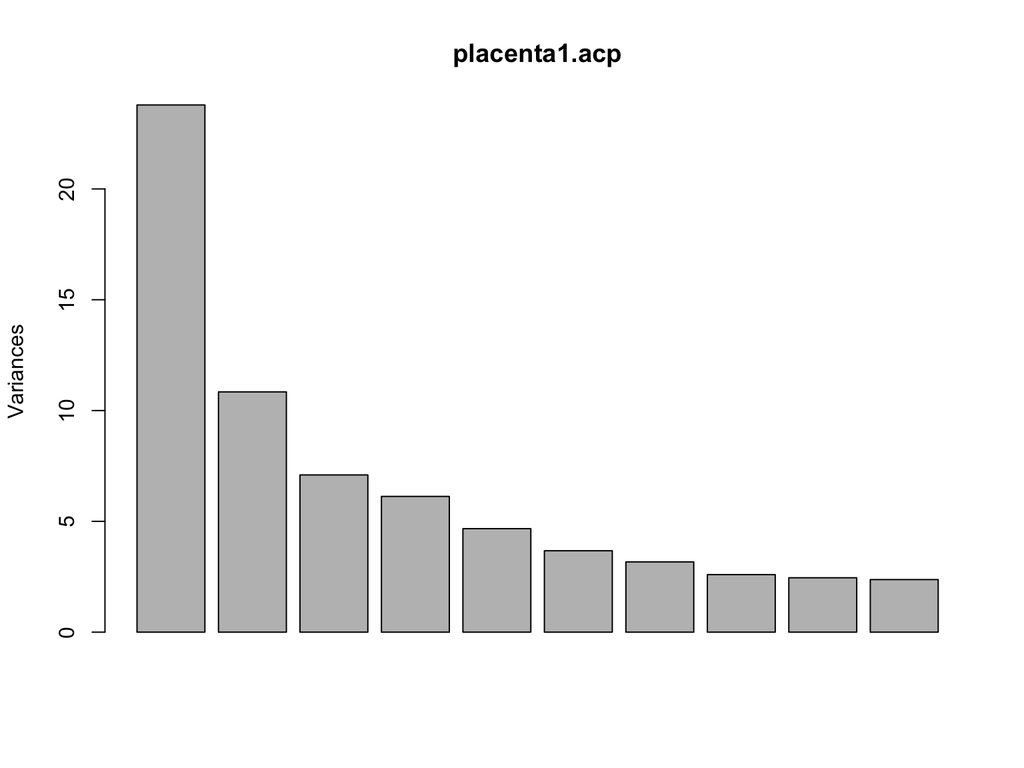

## ACP (normalisé)

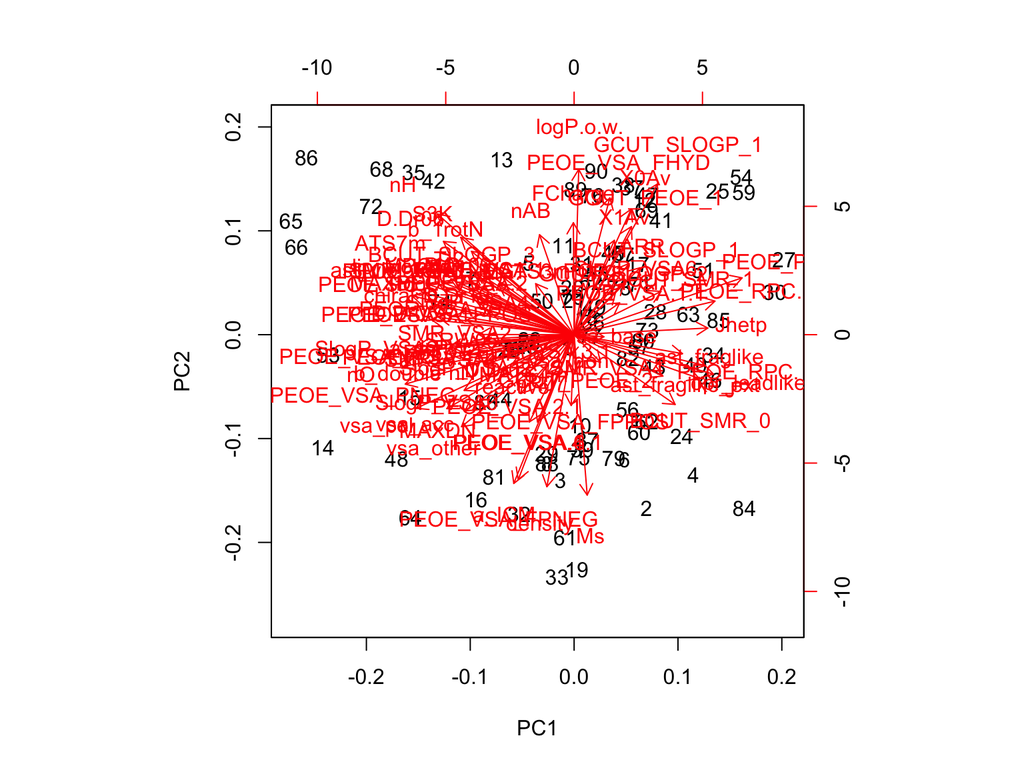

# Nettoyage des données

## Visualisation des données (boxplot)

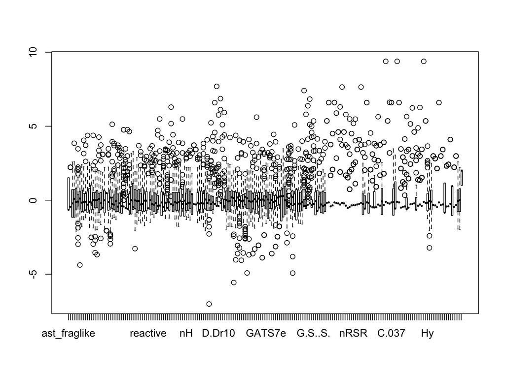

## Visualisation des données (histogramme)

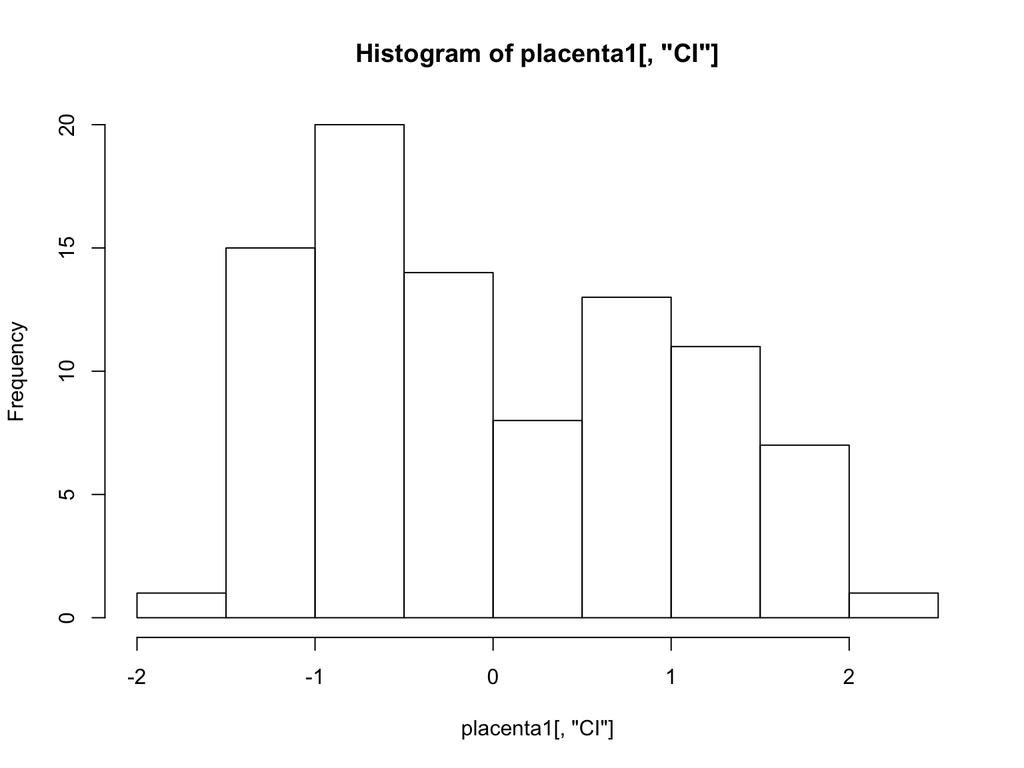

## Visualisation des données (plot)

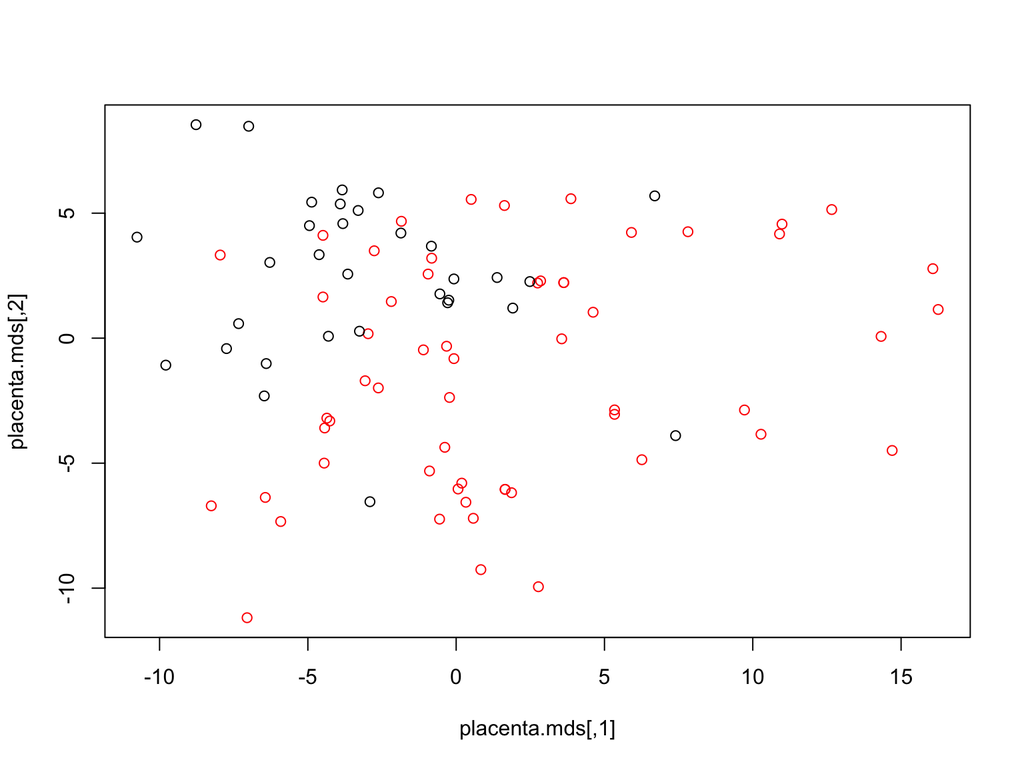

Rouge = Petite CI || Noir = Grande CI

# Prédiction

## La normalité des deux échantillons

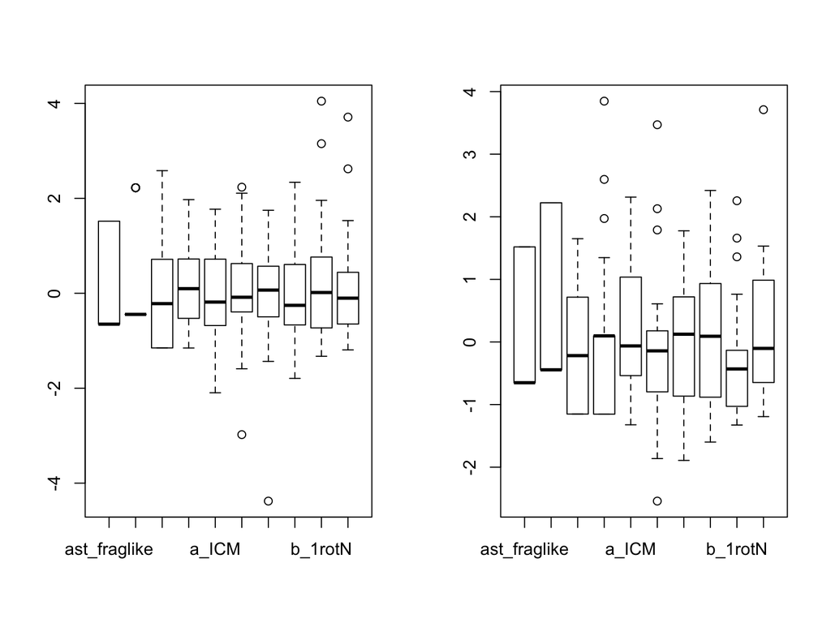

# Prédiction dans l’échantillon d’apprentissage pour 2 couches = 2 neurones et 1 neurone

## Prédiction dans l’échantillon d’apprentissage

Prédiction avec 2 couches de 2 neurones et 1 neurone PETITES CI

|  | 0 | 1 |
| --- | --- | --- |
| 0 | 19 | 0 |
| 1 | 3 | 38 |

## Les critères (échantillon d’apprentissage)

| Paramètres | Valeurs.2.1.app |
| --- | --- |
| Taux bon | 0.9500000 |
| Taux d’erreur | 0.0500000 |
| Sensibilité | 1.0000000 |
| Specifité | 0.8636364 |
| F1_Score | 0.9620253 |

## Prédiction dans l’échantillon de validation

Prédiction avec 2 couches de 2 neurones et 1 neurone PETITES CI

|  | 0 | 1 |
| --- | --- | --- |
| 0 | 9 | 1 |
| 1 | 1 | 19 |

## Les critères (échantillon de validation)

| Paramètres | Valeurs.2.1.validation |
| --- | --- |
| Taux bon | 0.9333333 |
| Taux d’erreur | 0.0666667 |
| Sensibilité | 0.9500000 |
| Specifité | 0.9000000 |
| F1_Score | 0.9500000 |

# Prédiction dans l’échantillon d’apprentissage pour 2 couches = 4 neurones et 2 neurones

## Prédiction dans l’échantillon d’apprentissage

Prédiction avec 2 couches de 4 neurones et 2 neurones PETITES CI

|  | 0 | 1 |
| --- | --- | --- |
| 0 | 21 | 0 |
| 1 | 1 | 38 |

## Les critères (échantillon d’apprentissage)

| Paramètres | Valeurs.4.2.app |
| --- | --- |
| Taux bon | 0.9833333 |
| Taux d’erreur | 0.0166667 |
| Sensibilité | 1.0000000 |
| Specifité | 0.9545455 |
| F1_Score | 0.9870130 |

## Prédiction dans l’échantillon de validation

Prédiction avec 2 couches de 4 neurones et 2 neurones PETITES CI

|  | 0 | 1 |
| --- | --- | --- |
| 0 | 9 | 0 |
| 1 | 1 | 20 |

## Les critères (échantillon de validation)

| Paramètres | Valeurs.4.2.validation |
| --- | --- |
| Taux bon | 0.9666667 |
| Taux d’erreur | 0.0333333 |
| Sensibilité | 1.0000000 |
| Specifité | 0.9000000 |
| F1_Score | 0.9756098 |

# Prédiction dans l’échantillon d’apprentissage pour 2 couches = 200 neurones et 100 neurones

## Prédiction dans l’échantillon d’apprentissage

Prédiction avec 2 couches de 200 neurones et 100 neurones PETITES CI

|  | 0 | 1 |
| --- | --- | --- |
| 0 | 20 | 0 |
| 1 | 2 | 38 |

## Les critères (échantillon d’apprentissage)

| Paramètres | Valeurs.200.100.app |
| --- | --- |
| Taux bon | 0.9666667 |
| Taux d’erreur | 0.0333333 |
| Sensibilité | 1.0000000 |
| Specifité | 0.9090909 |
| F1_Score | 0.9743590 |

## Prédiction dans l’échantillon de validation

Prédiction avec 2 couches de 200 neurones et 100 neurones PETITES CI

|  | 0 | 1 |
| --- | --- | --- |
| 0 | 10 | 0 |
| 1 | 0 | 20 |

## Les critères (échantillon de validation)

| Paramètres | Valeurs.200.100.validation |
| --- | --- |
| Taux bon | 1 |
| Taux d’erreur | 0 |
| Sensibilité | 1 |
| Specifité | 1 |
| F1_Score | 1 |

# Prédiction dans l’échantillon d’apprentissage pour 2 couches = 1 neurone et 2 neurones

## Prédiction dans l’échantillon d’apprentissage

Prédiction avec 2 couches de 1 neurone et 2 neurones PETITES CI

|  | 0 | 1 |
| --- | --- | --- |
| 0 | 20 | 6 |
| 1 | 2 | 32 |

## Les critères (échantillon d’apprentissage)

| Paramètres | Valeurs.1.2.app |
| --- | --- |
| Taux bon | 0.8666667 |
| Taux d’erreur | 0.1333333 |
| Sensibilité | 0.8421053 |
| Specifité | 0.9090909 |
| F1_Score | 0.8888889 |

## Prédiction dans l’échantillon de validation

Prédiction avec 2 couches de 1 neurone et 2 neurones PETITES CI

|  | 0 | 1 |
| --- | --- | --- |
| 0 | 8 | 7 |
| 1 | 2 | 13 |

## Les critères (échantillon de validation)

| Paramètres | Valeurs.1.2.validation |
| --- | --- |
| Taux bon | 0.7000000 |
| Taux d’erreur | 0.3000000 |
| Sensibilité | 0.6500000 |
| Specifité | 0.8000000 |
| F1_Score | 0.7428571 |

# Prédiction dans l’échantillon d’apprentissage pour 2 couches = 100 neurones et 200 neurones

## Prédiction dans l’échantillon d’apprentissage

Prédiction avec 2 couches de 100 neurones et 200 neurones PETITES CI

|  | 0 | 1 |
| --- | --- | --- |
| 0 | 22 | 0 |
| 1 | 0 | 38 |

## Les critères (échantillon d’apprentissage)

| Paramètres | Valeurs.100.200.app |
| --- | --- |
| Taux bon | 1 |
| Taux d’erreur | 0 |
| Sensibilité | 1 |
| Specifité | 1 |
| F1_Score | 1 |

## Prédiction dans l’échantillon de validation

Prédiction avec 2 couches de 100 neurones et 200 neurones PETITES CI

|  | 0 | 1 |
| --- | --- | --- |
| 0 | 9 | 0 |
| 1 | 1 | 20 |

## Les critères (échantillon de validation)

| Paramètres | Valeurs.100.200.validation |
| --- | --- |
| Taux bon | 0.9666667 |
| Taux d’erreur | 0.0333333 |
| Sensibilité | 1.0000000 |
| Specifité | 0.9000000 |
| F1_Score | 0.9756098 |

# Courbe ROC

## Courbe de clairance d’2 couches de 2 neurones et 1 neurone

## Courbe de clairance d’2 couches de 4 neurones et 2 neurones

## Courbe de clairance d’2 couches de 200 neurones et 100 neurones

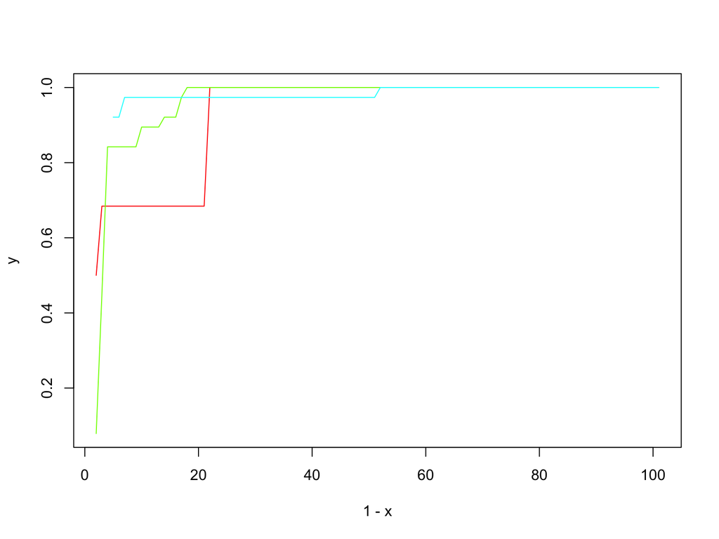

## Courbe de clairance d’2 couches de 1 neurone et 2 neurones

## Courbe de clairance d’2 couches de 100 neurones et 200 neurones

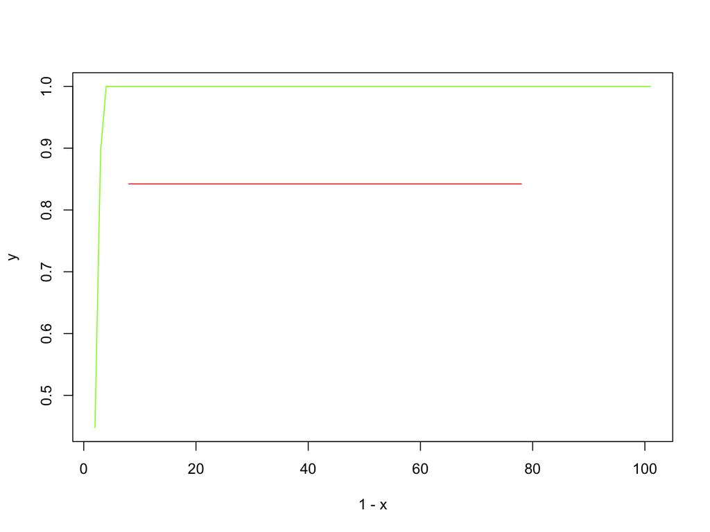